# An Introduction to Statistical Learning: Chapter 5 Labs

An Introduction to Statistical Learning: Chapter 5 Labs Kylie Foster 6 May 2019

## 5.3.1 The Validation Set Approach

```r
set.seed (1)
train <- sample(392, 196)
# returns a vector of 196 random values from the range 1 to 392 (without replacement).

lm_fit <- lm(mpg ∼ horsepower, data=Auto, subset = train) # using the subset option in
# lm() to fit a linear regression using only the observations corresponding to the
# training set

predict_all <- predict(lm_fit, Auto) # using predict() to estimate the response for all 392
# observations
attach (Auto)
# estimated test MSE for the linear regression fit:
mean((mpg - predict_all)[-train]^2)
```

```
## [1] 26.14142
```

```r
# this calculates the MSE of the
# 196 observations in the validation set. (takes the difference between
# predicted and actual, squares this difference and then finds the mean
# - it is the final step that results in a single number rather than a vector).
# The -train index selects only the observations that are not in the training set.
```

```r
# quadratic regression (fits horsepower + horsepower^2)
lm_fit2 <- lm(mpg ∼ poly(horsepower, 2), data = Auto, subset = train)
mean((mpg - predict(lm_fit2, Auto))[-train]^2) # test MSE for quadratic regression
```

```
## [1] 19.82259
```

```r
# cubic regression (fits horsepower + horsepower^2 + horsepower^3)
lm_fit3 <- lm(mpg ∼ poly(horsepower, 3), data = Auto, subset = train)
mean((mpg -predict (lm_fit3 ,Auto))[-train ]^2) # test MSE for cubic regression
```

```
## [1] 19.78252
```

```r
set.seed(2) # using a different seed to get a different training/test split
train <- sample(392, 196)
# linear regression
lm_fit <- lm(mpg ∼ horsepower, subset = train)
mean((mpg - predict(lm_fit, Auto))[-train ]^2) # test MSE
```

```
## [1] 23.29559
```

```r
# quadratic regression
lm_fit2 <- lm(mpg ∼ poly(horsepower, 2), data = Auto, subset = train)
mean((mpg - predict(lm_fit2, Auto))[-train ]^2) # test MSE
```

```
## [1] 18.90124
```

```r
# cubic regression
lm_fit3 <- lm(mpg ∼ poly(horsepower, 3), data = Auto, subset = train)
mean((mpg - predict(lm_fit3, Auto))[-train ]^2) # test MSE
```

```
## [1] 19.2574
```

Although the actual MSE values are slightly different, the results are consistent for two different seed values: a model that predicts `mpg` using a quadratic function of `horsepower` performs better than a model that involves only a linear function of `horsepower`, and there is little evidence in favor of a model that uses a cubic function of `horsepower`.

## 5.3.2 Leave-One-Out Cross-Validation

```r
glm_fit <- glm(mpg ∼ horsepower, data = Auto) # using glm to fit a linear regression model
coef(glm_fit)
```

```
## (Intercept)  horsepower
##  39.9358610  -0.1578447
```

```r
# identical results are obtained using lm()
lm_fit <- lm(mpg ∼ horsepower, data = Auto)
coef(lm_fit)
```

```
## (Intercept)  horsepower
##  39.9358610  -0.1578447
```

```r
glm_fit <- glm(mpg ∼ horsepower, data = Auto)
cv_err <- cv.glm(Auto, glm_fit)
cv_err$delta
```

```
## [1] 24.23151 24.23114
```

In this case (LOOCV) both values of `delta` correspond to: $CV_{(n)} = \frac{1}{n}\Sigma^n_{i=1} MSE_i$

This is the LOOCV estimate for the test MSE, which is the average of test errors for each of the `n` model fits.

```r
cv_error <- rep (0,5) #initialising vector
for (i in 1:5){
glm_fit <- glm(mpg ∼ poly(horsepower, i), data = Auto) # iteratively fits polynomial
# regressions for polynomials of order i = 1 to i = 5
cv_error[i] <- cv.glm(Auto, glm_fit)$delta[1] # computes the LOOCV cross-validation error,
# and stores it in the ith element of the vector cv_error
}
cv_error
```

```
## [1] 24.23151 19.24821 19.33498 19.42443 19.03321
```

## 5.3.3 k-Fold Cross-Validation

```r
set.seed(17)
cv_error_10 <- rep(0, 10) # initialising vector
for (i in 1:10) {
  glm_fit <- glm(mpg ∼ poly(horsepower, i), data = Auto)# iteratively fits polynomial
# regressions for polynomials of order i = 1 to i = 5
  cv_error_10[i] <- cv.glm (Auto, glm_fit, K=10)$delta[1] # 10-fold cross-validation
  }
cv_error_10
```

```
##  [1] 24.20520 19.18924 19.30662 19.33799 18.87911 19.02103 18.89609
##  [8] 19.71201 18.95140 19.50196
```

When LOOCV is performed the two numbers associated with delta are essentially the same. When we instead perform k-fold CV, then the two numbers associated with delta differ slightly. The first is the standard k-fold CV estimate, $CV_{(k)} = \frac{1}{k}\Sigma^k_{i=1}MSE_i$. The second is a bias corrected version.

## 5.3.4 The Bootstrap

Performing a bootstrap analysis in `R` involves two steps:

1. create a function that computes the statistic of interest.
2. use the `boot()` function to perform the bootstrap by repeatedly sampling observations from the data set with replacement.

#### Estimating the Accuracy of a Statistic of Interest

```r
alpha_fn <- function(data, index){# function takes as input the (X, Y)
  # data as well as a vector indicating which observations should be
  # used to estimate α
  X <- data$X[index]
  Y <- data$Y[index]
  return((var(Y) - cov(X,Y))/(var(X) + var(Y) -2*cov(X,Y))) # alpha
  }

alpha_fn(Portfolio, 1:100) # estimates α using all 100 observations
```

```
## [1] 0.5758321
```

```r
# the Portfolio data set is in the ISLR package

set.seed (1)
alpha_fn(Portfolio, sample(100, 100, replace = T))
```

```
## [1] 0.5963833
```

```r
# using sample() to randomly select 100 observations from the range
# 1 to 100, with replacement and then recomputing alpha hat using
# the new bootstrap data set.

boot(Portfolio, alpha_fn, R = 1000)
```

```
##
## ORDINARY NONPARAMETRIC BOOTSTRAP
##
##
## Call:
## boot(data = Portfolio, statistic = alpha_fn, R = 1000)
##
##
## Bootstrap Statistics :
##      original        bias    std. error
## t1* 0.5758321 -7.315422e-05  0.08861826
```

#### Estimating the Accuracy of a Linear Regression Model

```r
boot_fn <- function(data, index){
  return(coef(lm(mpg ∼ horsepower, data = data, subset = index)))
} # takes in the Auto data set and a set of indices for the
# observations, and returns the corresponding intercept and slope estimates for
# the linear regression model.

boot_fn(Auto, 1:392) # applying the function to the full set of 392 observations
```

```
## (Intercept)  horsepower
##  39.9358610  -0.1578447
```

```r
# in order to compute the estimates of β0 and β1 on the entire data set

set.seed (1)
# using boot_fn and sample() to to create bootstrap estimates
# for the intercept and slope terms by randomly sampling from among
# the observations with replacement
boot_fn(Auto, sample(392, 392, replace = T))
```

```
## (Intercept)  horsepower
##  38.7387134  -0.1481952
```

```r
# creating a different bootstrap estimate (because this sample() will
# use a different seed).
boot_fn(Auto, sample(392, 392, replace = T))
```

```
## (Intercept)  horsepower
##  40.0383086  -0.1596104
```

```r
# using the boot() function to compute the standard errors of 1,000
# bootstrap estimates for the intercept and slope terms
boot(Auto, boot_fn, 1000)
```

```
##
## ORDINARY NONPARAMETRIC BOOTSTRAP
##
##
## Call:
## boot(data = Auto, statistic = boot_fn, R = 1000)
##
##
## Bootstrap Statistics :
##       original      bias    std. error
## t1* 39.9358610  0.02972191 0.860007896
## t2* -0.1578447 -0.00030823 0.007404467
```

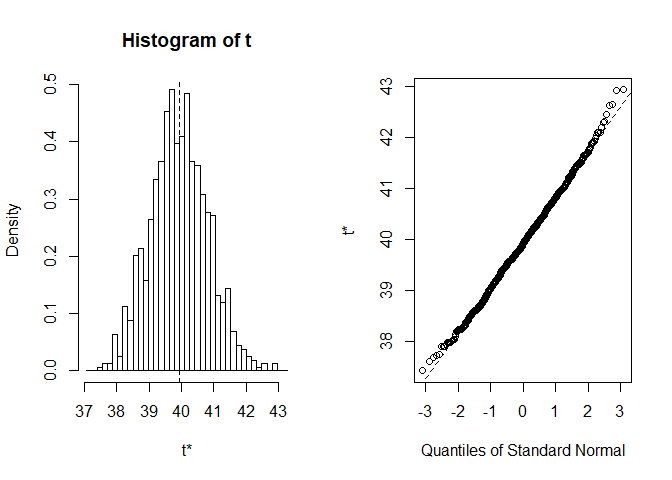

```r
plot(boot(Auto, boot_fn, 1000)) # checking what plot() displays for a boot object
```

```r
# Using standard formulas to compute the standard errors for the
# regression coefficients in the linear model
summary(lm(mpg ∼ horsepower, data = Auto))$coef
```

```
##               Estimate  Std. Error   t value      Pr(>|t|)
## (Intercept) 39.9358610 0.717498656  55.65984 1.220362e-187
## horsepower  -0.1578447 0.006445501 -24.48914  7.031989e-81
```

Comparing the bootstrap estimates and standard formula estimates for the standard errors of the coefficients using a quadratic fit to the data:

```r
boot_fn <- function(data, index){
  coefficients(lm(mpg ∼ horsepower + I(horsepower^2), data = data, subset = index))
} # new function calculating coefficients for the quadratic model

set.seed (1)
boot(Auto, boot_fn, 1000)
```

```
##
## ORDINARY NONPARAMETRIC BOOTSTRAP
##
##
## Call:
## boot(data = Auto, statistic = boot_fn, R = 1000)
##
##
## Bootstrap Statistics :
##         original        bias     std. error
## t1* 56.900099702  6.098115e-03 2.0944855842
## t2* -0.466189630 -1.777108e-04 0.0334123802
## t3*  0.001230536  1.324315e-06 0.0001208339
```

```r
summary(lm(mpg ∼ horsepower + I(horsepower^2), data = Auto))$coef
```

```
##                     Estimate   Std. Error   t value      Pr(>|t|)
## (Intercept)     56.900099702 1.8004268063  31.60367 1.740911e-109
## horsepower      -0.466189630 0.0311246171 -14.97816  2.289429e-40
## I(horsepower^2)  0.001230536 0.0001220759  10.08009  2.196340e-21
```